# Deep Learning- 課程 38 - An Introduction to FaceNet - Python Tutorial

''' 人工智慧- 進階課程 A.I Tutorials - Advanced Course - Deep Learning 教程 ''' 05 - 深度學習 教程 課程 38 - An Introduction to FaceNet 人臉網路 程式範例 - 人臉影像辨識 - Image Face Identify '''

''' >> 資料準備 >> A.I 人工智慧 - 進階課程 Advanced Course >> https://interactiveuandmetutorialsac.weebly.com/ >> 你我學習互動園地 >> https://interactiveuandmetutorials.weebly.com/ >> Python 程式語言 設計 >> https://pythonprogrammingtutorials.weebly.com/ >> 資料準備 >> 從 drive.google.com - https://drive.google.com/drive/folders/1pwQ3H4aJ8a6yyJHZkTwtjcL4wYWQb7bn - 點擊 Download - 下載 - Pretrained Model - facenet_keras.h5 >> 目錄結構: 課程 36 - Deep Learning- An Introduction to FaceNet.ipynb ├── data/ ├── └── images ├── ├── BillGates ├── ├── DonaldTrump ├── ├── LarryPage ├── ├── MarkZuckerberg ├── └── Test ├── model ├── ├── cv2 ├── ├── └── haarcascade_frontalface_alt2.xml ├── └── keras ├── └── model └── └── facenet_keras.h5 '''

## 面部識別技術 正在興起，並已進入我們生活的方方面面

- 從智慧/能手機，零售，辦公室，公園 ……無處不在

## FaceNet - 人臉網路

- A Unified Embedding for Face Recognition and Clustering ( 嵌入式 -人臉識別和聚類法)

## 論文參考

- https://arxiv.org/abs/1503.03832
- https://arxiv.org/pdf/1503.03832.pdf
- 近年來 透過深度學習以及 卷積神經網絡 (Convolutional Neural Network - CNN)
  - 不但開啟了人臉辨識領域 的新紀元
- 也讓 傳統的 LBP、HOG 搭配支援向量機 SVM 的辨識方法 - 顯得落伍
- 這些複雜的深度學習模型不但辨識率極高
  - 而且能識別的人數級別與相片總量也都以萬級來計算
  - 若與人眼來比較，這成績已經遠遠抛開 我們肉眼的能力
- 技術角度來看
- 當前的面部識別技術如下：
  - 特徵臉 Eigenfaces - 1991
  - 本地二進制模式直方圖 Local Binary Patterns Histograms (LBPH) - 1996
  - Fisherfaces - 1997
    - FLDA 最大化類間散佈與類內散佈的比率
    - Fisherface是一種與 Eigenfaces類似的技術
      - 但它旨在改善類的聚類
      - 雖然 Eigenfaces 依靠 PCA
      - Fischer 依靠LDA(又稱 Fischer的LDA) 來降低尺寸
  - 深度學習Deep Learning - 2014
- 大家可能有聽過 Google FaceNet
  - 它可是目前很流行的臉部識別技術
- 許多 影像辨識 的技術
  - 都需要有龐大的 數據集 - DateSets 來訓練模型
- 但 Facenet
  - 卻只需一張照片就能達到高度精準
- 2015年 由 Google 所提出的 FaceNet
  - 在 LFW(Labeled Faces in The Wild)人臉資料庫
  - 以 99.63% 的最佳成績 刷新了 記錄
- 由於其易於理解的演算原理 以及 應用方便
- 使得Facenet在眾多競爭者中(如 DeepFace、DeepID、Face++…等）異軍突起
  - 成為目前最流行的臉部識別技術
- 我們來瞭解一下 FaceNet -並且學習如何 來使用它

### 如果要執行 人臉識別

- 需要先知道 要解決什麼問題 ?
- 如果 使用深度學習 進行人臉識別任務
- 人臉識別 可以細分為三個 - 任務步驟
  1. 人臉驗證 Face Verification
     - 判斷是否為同一人
  2. 人臉識別 Face Recognition
     - 判斷是數據庫中哪個人
  3. 人臉聚類 Face Clustering
     - 尋找相似的人臉
- 用了什麼方法解決？
  - 使用與 Wrod2Vec 類似的方法
    - 1. 將人臉圖像通過一個長為128的向量表示
    - 1. 不同圖像之間的相似度
         - 通過兩個向量的歐幾里德距離來決定，距離小則相似度高，距離大則相似度低
    - 使用 Triplet loss 來替代普通多分類任務中的 Softmax
- 效果如何 ?
  - 在 LFW DataSet 和 Youtube Faces DB 中
    - 對比 當時最佳模型，錯誤率下降 30%

### 關鍵術語 TERMINOLOGY

- 人臉識別 Face Recognition 與 人臉檢測 Face Detection的不同
- 人臉檢測 Face Recognition
  - 目標是找到圖像中人臉周圍的邊界框坐標，以便可以裁剪並用於人臉識別。
- 人臉識別 Face Detection
  - 目標是識別個人。
- 人臉識別系統 Face Recognition System
  - 可以以兩種模式運行：
- 人臉驗證 Face Verification
  - 用於驗證人
  - 它將輸入的面部圖像與認證用戶的面部圖像進行比較
  - 這是1v1匹配或一對一匹配
  - 儘管看似簡單，但這很難實現，因為不可能有誤報的餘地！
- 面部識別 Facial Identification 或 面部識別 Facial Recognition
  - 這涉及嘗試將給定的面部與面部數據庫匹配
  - 這裡的挑戰
  - 是提出一個相似度度量
  - 該度量可用於量化一張臉與另一張臉的相似程度
    - 這是1vN的比較

[figure not shown]

## 模型架構 Model Architecture

- Facenet 架構

[figure not shown]

- 模型架構 Model Architecture
- Facenet 架構
  - 主要由以下步驟 所組成
1. Batch
   - Batch input layer 將臉孔圖片輸入模型
   - 這些圖片需已經 Facial alignment及resize處理
   - 發者使用 MTCNN 來進行臉孔偵測及校準
2. Deep Architecture
   - 用於特徵學習的 CNN 架構
     - 具彈性可以採用不同的網路
   - 剛推出時使用 Zeiler&Fergus 架構
   - Google的Inception v1 / 最新版改為 Inception ResNet-v2
     - 不同架構對於辨識結果有顯著的影響，
3. L2
   - L2 normalization 歸一化，讓資料能對應到一個超平面
4. Embedding
   - 經過 CNN 模型以及 L2 歸一化後生成的特徵向量 5 Triplet Loss
   - 從向量中取得一個 embedding 函數 f(x)
   - 讓相同臉孔之間的特徵距離要盡可能的小
     - 而不同臉孔 之間的特徵距離要盡可能的大
- GoogLeNet 的初始模型 - Inception Model

[figure not shown]

### 識別人臉 Recognizing Faces 在 深度學習 Deep Learning 的方法

### FaceNet

- Google 研究人員發布的 FaceNet 是一篇 論文
  - 在人臉識別準確性方面取得了重大進展
- 介紹了一種將面部像素數據投影到潛在空間上的新技術
  - 潛在變量的性質
    - 是相同的面將彼此靠近，而不同的面將相距較遠
- 使用卷積神經網絡方法 來 實現

[figure not shown]

- NN 是通用函數近似器 - Universal Function Approximaters
  - 1. 訓練學習
  - 1. 製定適合 當前問題的 - 損失函數 Loss Function
  - 1. 然後可以使用梯度下降 Gradient Descent (GD) 訓練 NN
       - 以最小化此損失函數 minimize this loss function

### - 損失的定義 - Definition Of The Loss

### Triplet Loss

[figure not shown]

- 在典型的分類任務中
  - 有固定數量的類
- 並且使用 Softmax 交叉熵損失 訓練網絡
- 但是
  - 在人臉識別問題上
  - 需要能夠比較兩個未知的人臉，並說出判斷 是否來自同一個人
- 對於 Softmax，這是不可行的
  - 不能為存在的每個面孔訓練一個巨大的分類器模型！
- 在這種情況下
- Triplet Loss
  - 是學習每張臉的良好 向量 /矢量表示 Vector Representation或嵌入Embeddings(潛在變量 Latent Variables)的一種方法
- 在嵌入空間中
  - 同一個人的臉部應彼此靠近，並形成間隔良好的簇 Clusters
  - 這使我們可以比較網絡從未見過的面孔

[figure not shown]

- Triplet Loss
- 為什麼不用 Softmax ?
- 通常在監督學習中
  - 有固定數量的 Fixed Number of Classes
  - 並使用 Softmax (Cross Entropy Loss 交叉熵損失） 來訓練網絡
- 但是
  - 在某些情況下
  - 我們需要具有可變數量的類
- 例如，在人臉識別中
  - 我們需要能夠比較兩個未知的面孔，並說出判斷它們 是否來自同一個人
- Triplet Loss
  - 試圖 在從一個人到 所有其他面孔的每對面孔之間 強制執行邊距(Try to Enforce a Margin)
  - 和 SVM 的 Margin 有點像
- 嵌入三元組(Triplets of Embeddings)
  - 1.0 Anchor 錨
  - 2.0 與錨同階級的 正面 - A Positive of The Same class as the Anchor
  - 3.0 與不同階級的 負面 - A Negative of The Different class as the Anchor
- 模型
  - 取得圖片不同的特徵並映射到歐幾里德的空間中（即計算特徵間的歐氏距離）
  - 所採用的作法是 Triplet loss
- 如下圖原論文中的圖示說明
- Triplet Loss 想法在於
  - 如果我們選取與該樣本最相像（差異最小）的錯誤臉孔，與最不像（差異度大）的正確臉孔
- 同時進行特徵訓練，迭代訓練至誤差降至最小，用以改進模型中的臉孔特徵定義
- 如此一來，便能得到最佳的辨識結果

[figure not shown]

- 損失的定義
- Triplets Loss 分為三類
- Easy Negative
  - Triplets Loss 中 有 = 0， d (a , p) + margin < d (a , n)
- Hard Negatives
  - Triplets Loss 中負數 Negatives 比正數 Positive 更靠近錨點 Anchor，即 d (a , n ) < d (a , p )
- Semi-Hard Negatives
  - Triplets Loss 中 負數 Negatives 不比正數 Positive 更靠近 錨點 Anchor，但仍然具有 正 Positive 損失：
    - d (a , p)< d(a ,n)< d(a , p) + margin
- 這些定義中的 每一個
  - 都取決 負數 Negative is 相對於錨 Anchor 和 Positive 的位置
- 因此
  - 可以將這三種類別擴展到 區域 Regions
    - Hard Negatives , Semi-Hard Negatives 或 Easy Negative
- Three Types of Negatives, Given an Anchor and a Positive

[figure not shown]

- 數學公式 表示

[figure not shown]

-即 對於嵌入空間 dd 上的 某個距離，三元組 (a，p，n) (a，p，n )的損失 Loss 為：

- For some distance on the embedding space dd, the loss of a triplet (a,p,n)(a,p,n) is:

$L = \max(d(a,p) - d(a,n) + margin, 0)L=max(d(a,p)−d(a,n)+margin,0)$

[figure not shown]

- 原始的 Facenet 論文中
- 他們為每對錨點和正點 選擇一個隨機的半硬負值
  - 並在這些三胞胎上進行訓練。
- 訓練好網絡後，它充當編碼器
  - 接收像素數據並生成嵌入
- 下圖 . Gif 所示
- 經過 MNIST 數據訓練的 類似網絡會生成嵌入
  - 形成簇 Clusters

[figure not shown]

- 整理一下
- 深度學習的面部識別系統 的檢測 的方式
  - CNN 將數據庫中內容 - 生成內容的嵌入存儲中
- 當搜索新面孔時
  1. 將生成其嵌入
  2. 並在該嵌入空間中搜索最近的點
- 如果最接近的點比閾值更近，則會找到人臉
  - 並從另一個DB中檢索關聯的元數據以識別個人
- 深度學習方法以進行人臉識別
- 在FaceNet之後
- 許多使用 深度學習
  - 都超過了人類水平的準確性

# 程式範例

- 驗證 比較 compares 列表中 相片的人 其差異度
- 忽略 警告訊息 Warning Message

```python
import warnings
warnings.filterwarnings("ignore")
```

- 檢查是否 - 有 GPU

```python
from tensorflow.python.client import device_lib
print (device_lib.list_local_devices())
```

```
[name: "/device:CPU:0"
device_type: "CPU"
memory_limit: 268435456
locality {
}
incarnation: 14192729475458879610
, name: "/device:GPU:0"
device_type: "GPU"
memory_limit: 3176441446
locality {
  bus_id: 1
  links {
  }
}
incarnation: 1051941652923814306
physical_device_desc: "device: 0, name: GeForce GTX 980M, pci bus id: 0000:01:00.0, compute capability: 5.2"
]
```

- os.environ 在 Jupyter Notebok 中 - 設置環境變量
- 初始化TensorFlow
  - 將 TensorFlow 限制為第一個GPU之前

```python
import os
os.environ["CUDA_DEVICE_ORDER"]="PCI_BUS_ID"
os.environ["CUDA_VISIBLE_DEVICES"]="0"
```

```python
!python -V
```

```
Python 3.6.7
```

```python
import keras
print(keras.__version__)
```

```
2.2.4
```

```python
%matplotlib inline
```

```python
import numpy as np
import os
import matplotlib.pyplot as plt
import cv2
from sklearn.decomposition import PCA
from mpl_toolkits.mplot3d import Axes3D
from mpl_toolkits.mplot3d import proj3d
from imageio import imread
from skimage.transform import resize
from scipy.spatial import distance
from keras.models import load_model
```

- OpenCV 的 Cascade classifier來偵測臉部
  - 不一定 跟 Facenet一樣要用 MTCNN

```python
cascade_path = 'model/cv2/haarcascade_frontalface_alt2.xml'
```

- 人像相片都放置於 ../data/images/Path

```python
image_dir_basepath = 'data/images/'
names = ['LarryPage', 'MarkZuckerberg', 'BillGates', 'DonaldTrump']
```

- Facenet model
  - 相片尺寸為 - 160×160

```python
image_size = 160
```

- 使用 Pretrained 的 Keras model - MS-Celeb- 1M

```python
model_path = 'model/keras/model/facenet_keras.h5'
model = load_model(model_path)
```

```python
model.summary()
```

```
__________________________________________________________________________________________________
Layer (type)                    Output Shape         Param #     Connected to
==================================================================================================
input_1 (InputLayer)            (None, 160, 160, 3)  0
__________________________________________________________________________________________________
Conv2d_1a_3x3 (Conv2D)          (None, 79, 79, 32)   864         input_1[0][0]
__________________________________________________________________________________________________
Conv2d_1a_3x3_BatchNorm (BatchN (None, 79, 79, 32)   96          Conv2d_1a_3x3[0][0]
__________________________________________________________________________________________________
Conv2d_1a_3x3_Activation (Activ (None, 79, 79, 32)   0           Conv2d_1a_3x3_BatchNorm[0][0]
__________________________________________________________________________________________________
Conv2d_2a_3x3 (Conv2D)          (None, 77, 77, 32)   9216        Conv2d_1a_3x3_Activation[0][0]
__________________________________________________________________________________________________
Conv2d_2a_3x3_BatchNorm (BatchN (None, 77, 77, 32)   96          Conv2d_2a_3x3[0][0]
__________________________________________________________________________________________________
Conv2d_2a_3x3_Activation (Activ (None, 77, 77, 32)   0           Conv2d_2a_3x3_BatchNorm[0][0]
__________________________________________________________________________________________________
Conv2d_2b_3x3 (Conv2D)          (None, 77, 77, 64)   18432       Conv2d_2a_3x3_Activation[0][0]
__________________________________________________________________________________________________
Conv2d_2b_3x3_BatchNorm (BatchN (None, 77, 77, 64)   192         Conv2d_2b_3x3[0][0]
__________________________________________________________________________________________________
Conv2d_2b_3x3_Activation (Activ (None, 77, 77, 64)   0           Conv2d_2b_3x3_BatchNorm[0][0]
__________________________________________________________________________________________________
MaxPool_3a_3x3 (MaxPooling2D)   (None, 38, 38, 64)   0           Conv2d_2b_3x3_Activation[0][0]
__________________________________________________________________________________________________
Conv2d_3b_1x1 (Conv2D)          (None, 38, 38, 80)   5120        MaxPool_3a_3x3[0][0]
__________________________________________________________________________________________________
Conv2d_3b_1x1_BatchNorm (BatchN (None, 38, 38, 80)   240         Conv2d_3b_1x1[0][0]
__________________________________________________________________________________________________
Conv2d_3b_1x1_Activation (Activ (None, 38, 38, 80)   0           Conv2d_3b_1x1_BatchNorm[0][0]
__________________________________________________________________________________________________
Conv2d_4a_3x3 (Conv2D)          (None, 36, 36, 192)  138240      Conv2d_3b_1x1_Activation[0][0]
__________________________________________________________________________________________________
Conv2d_4a_3x3_BatchNorm (BatchN (None, 36, 36, 192)  576         Conv2d_4a_3x3[0][0]
__________________________________________________________________________________________________
Conv2d_4a_3x3_Activation (Activ (None, 36, 36, 192)  0           Conv2d_4a_3x3_BatchNorm[0][0]
__________________________________________________________________________________________________
Conv2d_4b_3x3 (Conv2D)          (None, 17, 17, 256)  442368      Conv2d_4a_3x3_Activation[0][0]
__________________________________________________________________________________________________
Conv2d_4b_3x3_BatchNorm (BatchN (None, 17, 17, 256)  768         Conv2d_4b_3x3[0][0]
```

[output cut: 856 more lines]

```
Block8_6_ScaleSum (Lambda)      (None, 3, 3, 1792)   0           Block8_5_Activation[0][0]
                                                                 Block8_6_Conv2d_1x1[0][0]
__________________________________________________________________________________________________
AvgPool (GlobalAveragePooling2D (None, 1792)         0           Block8_6_ScaleSum[0][0]
__________________________________________________________________________________________________
Dropout (Dropout)               (None, 1792)         0           AvgPool[0][0]
__________________________________________________________________________________________________
Bottleneck (Dense)              (None, 128)          229376      Dropout[0][0]
__________________________________________________________________________________________________
Bottleneck_BatchNorm (BatchNorm (None, 128)          384         Bottleneck[0][0]
==================================================================================================
Total params: 22,808,144
Trainable params: 22,779,312
Non-trainable params: 28,832
__________________________________________________________________________________________________
```

- 圖像白化（whitening）
  - 用於對過度曝光或低曝光的圖片進行處理
  - 處理的方式
    - 改變圖像的平均 像素值為 0
    - 改變圖像的方差 為單位方差 1
- 使用 L1 或 L2 標準化圖像
  - 可強化其特徵

```python
def prewhiten(x):
    if x.ndim == 4:
        axis = (1, 2, 3)
        size = x[0].size
    elif x.ndim == 3:
        axis = (0, 1, 2)
        size = x.size
    else:
        raise ValueError('Dimension should be 3 or 4')

    mean = np.mean(x, axis=axis, keepdims=True)
    std = np.std(x, axis=axis, keepdims=True)
    std_adj = np.maximum(std, 1.0/np.sqrt(size))
    y = (x - mean) / std_adj
    return y

def l2_normalize(x, axis=-1, epsilon=1e-10):
    output = x / np.sqrt(np.maximum(np.sum(np.square(x), axis=axis, keepdims=True), epsilon))
    return output
```

- 偵測並取得臉孔 area
- resize為模型要求的尺寸
  - 下方例子並未作 alignment

```python
def load_and_align_images(filepaths, margin):
    cascade = cv2.CascadeClassifier(cascade_path)

    aligned_images = []
    for filepath in filepaths:
        img = imread(filepath)

        faces = cascade.detectMultiScale(img,
                                         scaleFactor=1.1,
                                         minNeighbors=3)
        (x, y, w, h) = faces[0]
        cropped = img[y-margin//2:y+h+margin//2,
                      x-margin//2:x+w+margin//2, :]
        aligned = resize(cropped, (image_size, image_size), mode='reflect')
        aligned_images.append(aligned)

    return np.array(aligned_images)
```

- 同上方的 圖片
  - 依序取得各圖片人臉的臉孔特徵向量
  - 再與 進行歐氏距離 計算

```python
def calc_embs(filepaths, margin=10, batch_size=1):
    aligned_images = prewhiten(load_and_align_images(filepaths, margin))
    pd = []
    for start in range(0, len(aligned_images), batch_size):
        pd.append(model.predict_on_batch(aligned_images[start:start+batch_size]))
    embs = l2_normalize(np.concatenate(pd))

    return embs
```

```python
def calc_dist(img_name0, img_name1):
    return distance.euclidean(data[img_name0]['emb'], data[img_name1]['emb'])

def calc_dist_plot(img_name0, img_name1):
    print(calc_dist(img_name0, img_name1))
    plt.subplot(1, 2, 1)
    plt.imshow(imread(data[img_name0]['image_filepath']))
    plt.subplot(1, 2, 2)
    plt.imshow(imread(data[img_name1]['image_filepath']))
```

```python
data = {}
for name in names:
    image_dirpath = image_dir_basepath + name
    image_filepaths = [os.path.join(image_dirpath, f) for f in os.listdir(image_dirpath)]
    embs = calc_embs(image_filepaths)
    for i in range(len(image_filepaths)):
        data['{}{}'.format(name, i)] = {'image_filepath' : image_filepaths[i],
                                        'emb' : embs[i]}
```

```
0.6467306613922119
```

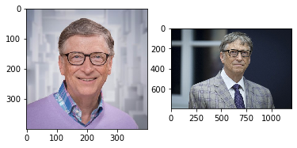

```python
calc_dist_plot('BillGates0', 'BillGates1')
```

```
1.318315029144287
```

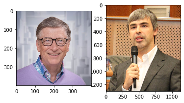

```python
calc_dist_plot('BillGates0', 'LarryPage0')
```

```
0.6520649194717407
```

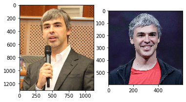

```python
calc_dist_plot('LarryPage0', 'LarryPage1')
```

```
1.332726240158081
```

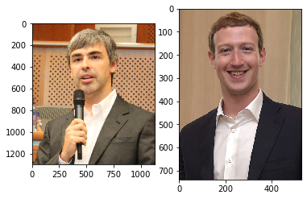

```python
calc_dist_plot('LarryPage0', 'MarkZuckerberg1')
```

```
0.5808740854263306
```

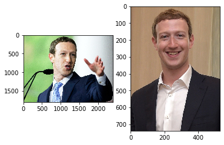

```python
calc_dist_plot('MarkZuckerberg0', 'MarkZuckerberg1')
```

```
1.382260799407959
```

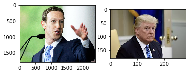

```python
calc_dist_plot('MarkZuckerberg0', 'DonaldTrump1')
```

```
0.5178813338279724
```

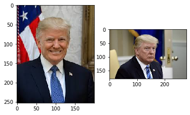

```python
calc_dist_plot('DonaldTrump0', 'DonaldTrump1')
```

```
1.247449517250061
```

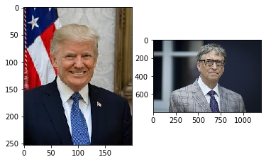

```python
calc_dist_plot('DonaldTrump0', 'BillGates1')
```

- Plot

```python
X = []
for v in data.values():
    X.append(v['emb'])
pca = PCA(n_components=3).fit(X)
```

```python
X_DonaldTrump    = [] # added
X_BillGates      = []
X_LarryPage      = []
X_MarkZuckerberg = []
for k, v in data.items():
    if 'Bill' in k:
        X_BillGates.append(v['emb'])
    elif 'Larry' in k:
        X_LarryPage.append(v['emb'])
    elif 'Mark' in k:
        X_MarkZuckerberg.append(v['emb'])
    elif 'Donald' in k:
        X_DonaldTrump.append(v['emb'])    # added


Xd_BillGates = pca.transform(X_BillGates)
Xd_LarryPage = pca.transform(X_LarryPage)
Xd_MarkZuckerberg = pca.transform(X_MarkZuckerberg)
Xd_DonaldTrump = pca.transform(X_DonaldTrump) # added
```

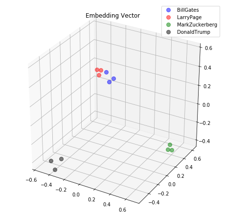

```python
fig = plt.figure(figsize=(8,8))
ax = fig.add_subplot(111, projection='3d')
plt.rcParams['legend.fontsize'] = 10
ax.plot(Xd_BillGates[:,0], Xd_BillGates[:,1], Xd_BillGates[:,2],
        'o', markersize=8, color='blue', alpha=0.5, label='BillGates')
ax.plot(Xd_LarryPage[:,0], Xd_LarryPage[:,1], Xd_LarryPage[:,2],
        'o', markersize=8, color='red', alpha=0.5, label='LarryPage')
ax.plot(Xd_MarkZuckerberg[:,0], Xd_MarkZuckerberg[:,1], Xd_MarkZuckerberg[:,2],
        'o', markersize=8, color='green', alpha=0.5, label='MarkZuckerberg')

ax.plot(Xd_DonaldTrump[:,0], Xd_DonaldTrump[:,1], Xd_DonaldTrump[:,2],    # added
        'o', markersize=8, color='black', alpha=0.5, label='DonaldTrump') # added


plt.title('Embedding Vector')
ax.legend(loc='upper right')

plt.show()
```

```python
%matplotlib inline
```

```python
import numpy as np
import os
import matplotlib.pyplot as plt
import cv2
from sklearn.svm import SVC
from sklearn.preprocessing import LabelEncoder
from imageio import imread
from skimage.transform import resize
from keras.models import load_model
```

```python
def train(dir_basepath, names, max_num_img=10):
    labels = []
    embs = []
    for name in names:
        dirpath = os.path.abspath(dir_basepath + name)
        filepaths = [os.path.join(dirpath, f) for f in os.listdir(dirpath)][:max_num_img]
        embs_ = calc_embs(filepaths)
        labels.extend([name] * len(embs_))
        embs.append(embs_)

    embs = np.concatenate(embs)
    le = LabelEncoder().fit(labels)
    y = le.transform(labels)
    clf = SVC(kernel='linear', probability=True).fit(embs, y)
    return le, clf
```

```python
def infer(le, clf, filepaths):
    embs = calc_embs(filepaths)
    pred = le.inverse_transform(clf.predict(embs))
    return pred
```

```python
le, clf = train(image_dir_basepath, names)
```

```python
test_dirpath = os.path.join(image_dir_basepath, 'Test')
test_filepaths = [os.path.join(test_dirpath, f) for f in os.listdir(test_dirpath)]
```

```python
pred = infer(le, clf, test_filepaths)
```

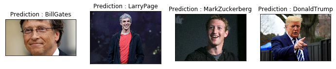

```python
fig, axes = plt.subplots(1, 4, figsize=(12, 6))

for i in range(4):
    axes[i].set_title('Prediction : '+str(pred[i]))
    axes[i].imshow(imread(test_filepaths[i]))
    axes[i].set_xticks([])
    axes[i].set_yticks([])
plt.show()
```

# 讓我們繼續 的看下去